# 84th MORS Text Analysis

The Center for Army Analysis was asked by the Military Operations Research Society (MORS) to analyze the texts of abstracts submited for the 84th MORS symposium. The goal of the analysis was to determine if the abstracts would form clusters that are different than their current clustering (by working groups).

## Summary

Do the abstracts cluster in a way that makes reorganizing the MORS working groups logical and worthwhile?

The short answer is no. Many of the unique terms found in the corpus are also unique to an abstract. In other words the terms are not shared across abstracts. My hypothesis is that this is because MORS does not reject many abstracts sent for submission. This would lead to abstracts that are loosely tied to WG but not very specific to the WG.

The first piece of data that we have is the sparsity of the Document Term Matrix which lists all of the key terms in the corpus and how many times they appear in each document.

```r
dtm
```

```
## <<DocumentTermMatrix (documents: 383, terms: 6760)>>
## Non-/sparse entries: 30954/2558126
## Sparsity           : 99%
## Maximal term length: 26
## Weighting          : term frequency (tf)
```

The sparsity value of 99% implies that most terms appear only in a few documents a piece; terms are not shared between documents and tend to be specific to a handful of documents. There are 6760 terms in the generated DTM. If we run a command to reduce the sparcity of the matrix to say a maximum of 90%:

```r
removeSparseTerms(dtm,0.90)
```

```
## <<DocumentTermMatrix (documents: 383, terms: 98)>>
## Non-/sparse entries: 6081/31453
## Sparsity           : 84%
## Maximal term length: 13
## Weighting          : term frequency (tf)
```

We’re left with a sparsity of 84% and only 98 terms remaining. This is further evidence that the corpus words are not shared between document because the only way to reduce the sparsity of the matrix is to remove terms.

However, all is not lost.

To determine the number of clusters we try to minimize the sum of squares error within each group.

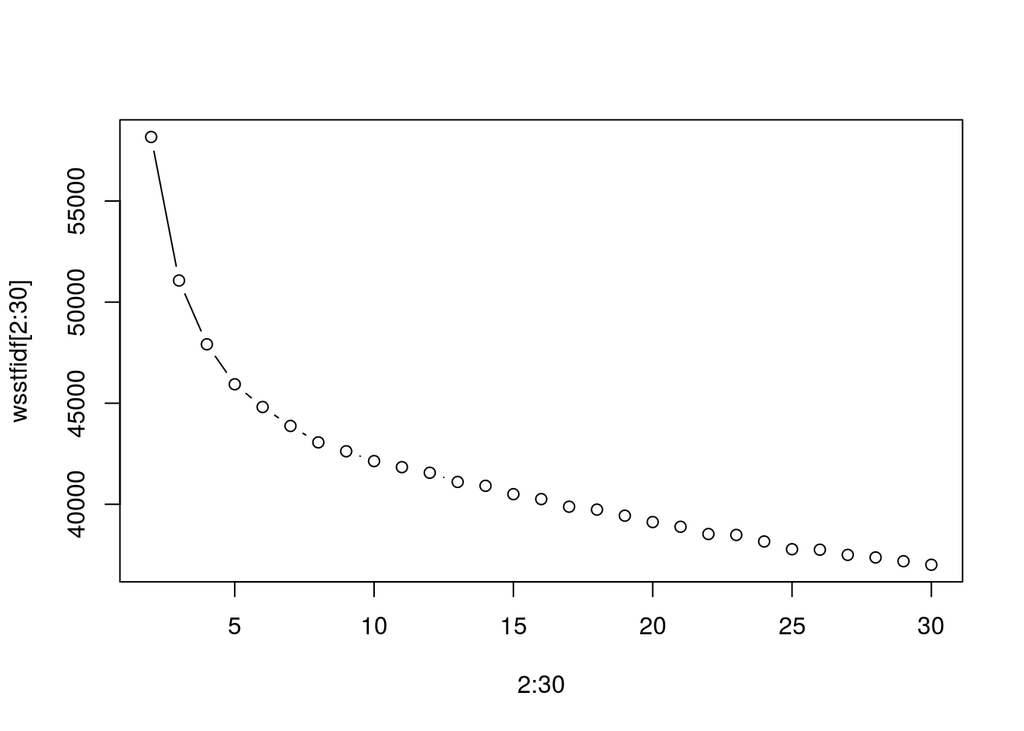

```r
mattfidf <- weightTfIdf(dtm)
disttfidf <- dist(mattfidf, method = "manhattan")
wsstfidf <- 2:30
for (i in 2:30) wsstfidf[i] <- sum(kmeans(disttfidf, centers = i, nstart = 25)$withinss)
plot(2:30, wsstfidf[2:30], type = "b")
```

We’re looking for the point where the rate of change for the SS error begins to decrease. You can see this around 5-10 clusters.

```r
sphericalmeans <- skmeans(mattfidf, 10)
sphericalmeans$cluster
```

```
##   1   2   3   4   5   6   7   8   9  10  11  12  13  14  15  16  17  18
##   4   7   5   4   1   4   2   4   6   1   2   9   4   4   6   8   3   1
##  19  20  21  22  23  24  25  26  27  28  29  30  31  32  33  34  35  36
##   3   4   5   4   5   1   8   3   4   6   6   4   4   8   6   2   5   5
##  37  38  39  40  41  42  43  44  45  46  47  48  49  50  51  52  53  54
##   4   2   5   6   6   6   6   4   2   5   4   2   4   4   4   9   4   8
##  55  56  57  58  59  60  61  62  63  64  65  67  68  69  70  71  72  73
##   4   1   7   4   7   5   9   6   5   3   4   9   4   8   6   9   5   1
##  74  75  76  77  78  79  80  81  82  83  84  85  86  87  88  89  90  91
##   4   8   4   6   5   4   8   1   6   6   4   7   4   7   5   6   9  10
##  92  93  94  95  96  97  98  99 100 101 102 103 104 105 106 107 108 109
##   8   4  10   5   4   5   1   5   5   4  10   5   5   4   4   8   4   4
## 110 111 112 113 114 115 116 117 118 119 120 121 122 123 124 125 126 127
##   6   6   8   7   6   6   6   1   1   5   7   4   8   5   8   6   5   1
## 128 129 130 131 132 133 134 135 136 137 138 139 140 141 142 143 144 145
```

[output cut: 29 more lines]

The 10 words associated with each cluster are:

```r
mfrq_words_per_cluster(sphericalmeans, dtm, unique = FALSE)
```

```
## $CLUSTER_1
##  operational          new       system     approach     decision
##           29           24           20           17           17
##        model        study presentation      process    scenarios
##           17           17           15           15           13
##
## $CLUSTER_2
##     energy   software      model    systems       army      cyber
##         21         15         14         13         12         12
##  developed      force simulation    process
##         11         11         11         10
##
## $CLUSTER_3
##      model      force    mission   training       army      based
##         16         14         13         13         12         12
## operations        red    teaming       mors
##         12         12         12         10
##
## $CLUSTER_4
##        army operational       model       force      system         air
##          52          45          44          39          39          38
##  operations     support      combat       study
##          37          37          35          35
##
## $CLUSTER_5
##      systems        model      mission       system         army
##           52           50           47           38           35
## capabilities  performance        force presentation      provide
##           31           31           30           30           30
##
## $CLUSTER_6
##     decision        model          air  operational      support
##           34           34           28           23           22
##         cost presentation      program        study  development
##           21           20           20           20           19
##
## $CLUSTER_7
##        model     approach         army         cost     modeling
##           21           16           16           14           14
##    developed     military presentation          air  information
##           12           12           12           11           11
##
## $CLUSTER_8
##       system         cost      process        study         army
##           32           27           27           24           23
##      defense  performance         risk capabilities        force
##           22           22           22           21           21
##
## $CLUSTER_9
##      force   military      model     models   manpower simulation
##         22         20         19         16         15         15
##    medical       time    support        air
##         14         14         13         12
##
## $CLUSTER_10
##         cost   capability        model requirements     schedule
##           20           15           13           13           12
##       system        based        joint         mors      process
##           12           11           11           11           10
```

The 10 unique words associated with each cluster are:

```r
mfrq_words_per_cluster(sphericalmeans, dtm, unique = TRUE)
```

```
## $CLUSTER_1
##         othrs           aav        clinic         gator decontaminant
##             8             5             5             5             4
##        dmttse      ensemble          mine      undersea          bicc
##             4             4             4             4             3
##
## $CLUSTER_2
##      beeps biometrics      squad      alpha        mdt      rifle
##          8          5          5          4          4          4
##        bec      fuzzy     junior     manual
##          3          3          3          3
##
## $CLUSTER_3
##       fbar        mtc        abi     afotec        dst       fuze
##          6          6          5          5          5          5
##       hash contagious     draccm      nptus
##          5          4          3          3
##
## $CLUSTER_4
##        otter         afsc      cluster         htns       satcom
##           10            7            6            6            6
##         tank       cosage         cwam        fwtnp homelessness
##            6            5            5            5            5
##
## $CLUSTER_5
##        tenants         amulet        nonarmy            esp      promotion
##              8              7              7              6              6
##            qol  reimbursement           cops            mmh sustainability
##              6              6              5              5              5
##
## $CLUSTER_6
##    dhs    ied    lbc motion   coes   mcrc    mds  syria    wia   amac
##      9      6      6      5      4      4      4      4      4      3
##
## $CLUSTER_7
##     trust     niirs     crowd employees      jsps    advise      cgfs
##         7         6         5         5         5         4         4
##   insider     mitre  employee
##         4         4         3
##
## $CLUSTER_8
##           ped          srdr          acpa          mumt         nvesd
##             7             7             6             4             4
##         opral          surf           agr         crude institutional
##             4             4             3             3             3
##
## $CLUSTER_9
##        icd      cobra        png  terrorism     afghan       brac
##          6          5          5          5          4          4
##      cdmps centrality       esbc       sdsr
##          4          4          4          4
##
## $CLUSTER_10
##    subsystem        nexus    splitting      ducting          edh
##            6            5            5            4            3
##  evaporation    integrity multiplexing        plays    boltzmann
##            3            3            3            3            2
```

## Preprocessing

### Abstract Corpus

```r
abstracts
```

```
## <<VCorpus>>
## Metadata:  corpus specific: 0, document level (indexed): 0
## Content:  documents: 383
```

```r
dtm
```

```
## <<DocumentTermMatrix (documents: 383, terms: 6760)>>
## Non-/sparse entries: 30954/2558126
## Sparsity           : 99%
## Maximal term length: 26
## Weighting          : term frequency (tf)
```

```r
## This shows you words 150 to 160 for document 17.  These words did no appear within the document (but did elsewhere in the corpus)
inspect(dtm[17, 150:160])
```

```
## <<DocumentTermMatrix (documents: 1, terms: 11)>>
## Non-/sparse entries: 0/11
## Sparsity           : 100%
## Maximal term length: 11
## Weighting          : term frequency (tf)
##
##     Terms
## Docs adversely advice advise advisors advocate advocated aegis aerial
##   17         0      0      0        0        0         0     0      0
##     Terms
## Docs aeromedical aeronautics aerosol
##   17           0           0       0
```

## Distance and normalization calculations

From the DTM we can begin to cluster the abstracts. Clustering algorithms depend on the notion of distance in order to determine how documents are similar or different. The distance calculation occurs on a normalized or weighted DTM. This is to ensure that longer documents, for frequent words do not disproportionately affect the results. The most common method and one used here is the term frequency - inverse document frequency. So first we must calculate a distance matrix - this tells you how “far” away each document is from each other.

```r
#normalization Calcs

mattfidf <- weightTfIdf(dtm)


disttfidf <- dist(mattfidf, method = "manhattan")
distnorm <- dist(matnormal, method = "manhattan")
```

Clustering algorithms require an input that tells the algorithm the number of clusters to make. There are several heuristic methods for determing what this number should be. One of the most common ones is to plot the sum of squares error for each group. The point on the plot where the error starts to level out (the elbow in the curve) is a good starting point for how many clusters you should create.

```r
wss <- 2:30
for (i in 2:30) wss[i] <- sum(kmeans(distnorm, centers = i, nstart = 25)$withinss)
```

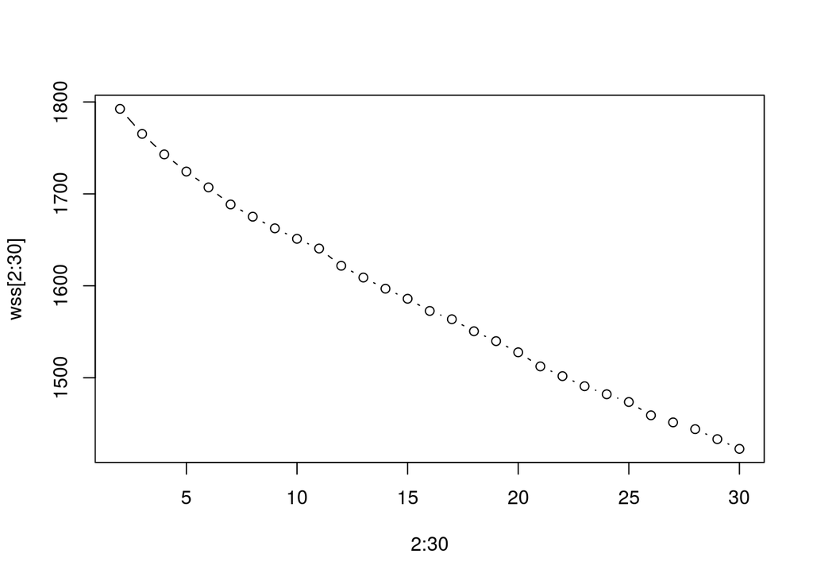

```r
plot(2:30, wss[2:30], type = "b")
```

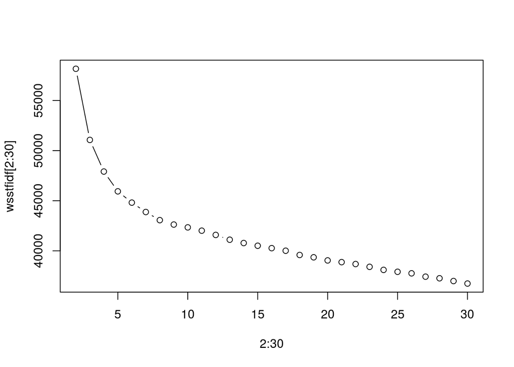

```r
wsstfidf <- 2:30
for (i in 2:30) wsstfidf[i] <- sum(kmeans(disttfidf, centers = i, nstart = 25)$withinss)
plot(2:30, wsstfidf[2:30], type = "b")
```

Using the tfidf weighting this implies that there should be about 5 +/-1 with a max of 10 clusters.

```r
tfidfclust <- hclust(distnorm, "ward.D2")

dendroNetwork(tfidfclust,  height = 6000, width = 2000, fontSize = 6,
              textColour = c("brown","light blue","pink","gray","tan","red", "blue", "orange","black","green")[cutree(tfidfclust, 5)],
              treeOrientation = "horizontal",zoom = TRUE,linkType = "elbow",nodeStroke="grey")
```

[interactive chart not shown]

```r
normclust <- hclust(distnorm, "ward.D2")

dendroNetwork(normclust,  height = 6000, width = 2000, fontSize = 6,
              textColour = c("brown","light blue","pink","gray","tan","red", "blue", "orange","black","green")[cutree(normclust, 5)],
              treeOrientation = "horizontal",zoom = TRUE,linkType = "elbow",nodeStroke="grey")
```

[interactive chart not shown]